# Demonstrate how disparate impact statistics can fail

Max Griswold

2024-01-11

## Introduction

This notebook demonstrates a simplified example of how we might conduct simulations. The setup concerns a landlord determining whether to accept a tenant’s rental application, based on their income and former-incarceration status. In each of the three scenarios below, the landlord aims to deny tenancy to applicants based on their race.

## Problem setup

I determined the probability of former incarceration status using data from [DOJ-OJP](https://bjs.ojp.gov/content/pub/pdf/Llgsfp.pdf), monthly earnings based off [census income](https://www.census.gov/library/publications/2023/demo/p60-279.html), and the effect of incarceration status on monthly earnings, stratified by race, from estimates in [Western, 2017](https://scholar.harvard.edu/files/brucewestern/files/racial_inequality_in_employment_and_earnings_after_incarceration.pdf).

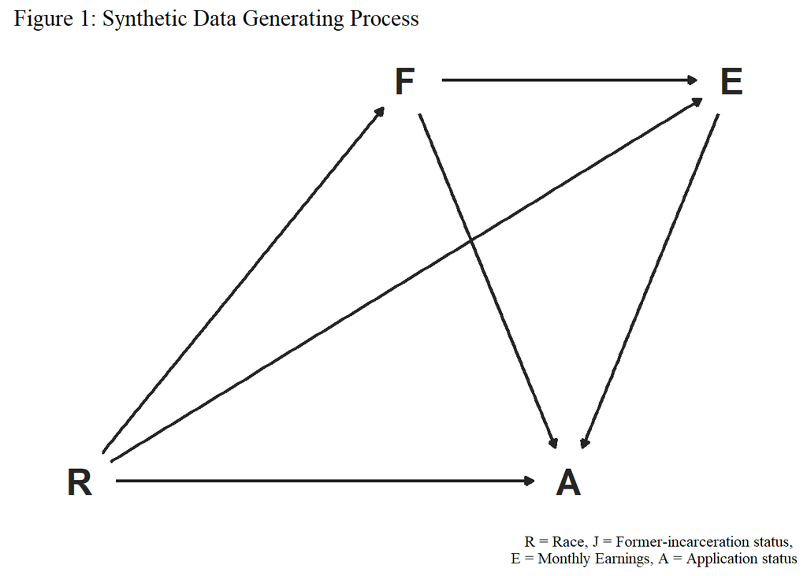

I set up the following decision scenarios for the landlord:

1. The landlord engages in direct discrimination: If the applicant is black, they offer a unit to them 25% less often than a comparable white candidate.
2. The landlord attempts to obscure their motive by only denying tenancy to a fraction of applicants. Every third black applicant they encounter, they deny their tenancy 75% more often.
3. The landlord puts more weight on former-incarceration status to decide if they deny an applicant tenancy. They choose a probability of denying tenancy based on former-incarceration status so they deny tenancy to an equal proportion of black-to-white tenants as in the first two scenarios.

Across all scenarios, the same ratio of black-to-white applicants are denied tenancy. I used monte-carlo simulation to generate 500 synthetic datasets and varied the sample size of applicants between 200 and 4000.

For each simulation and scenario, I regressed a tenant’s application status (accepted or denied) on the tenant’s race, former-incarceration status, and monthly earnings using a binomial regression with a logit link. This is a routine model used to detect disparate impact ([Ayres, 2010](https://www.law.upenn.edu/live/files/1138-ayresincludedvariablebiaspdf); [Jung et al., 2023](https://5harad.com/papers/included-variable-bias.pdf))

I then obtained the estimated p-value for the beta-coefficient on race and used the regression equation to calculate an estimate for the ratio of black-to-white applicants denied tenancy. Finally, I took the mean of these estimates across simulation iterations.

## Results and discussion

To meet the standards for disparate impact, the protected class needs to be selected as an applicant less than 80% of the time (the four-fifths rule) and this effect needs to be significant at the 0.05 significance level. Since we set up the scenarios, we know for a fact that landlords are discriminating against black applicants 25% more often than white applicants. However, can the models detect this effect?

Figure 2 displays the estimated rate at which black applicants are selected for a unit compared to white applicants. For scenario 1 and 2, the model is able to detect a disparity of roughly 70%. For scenario 3, the estimated disparity is close to 100%. While scenario 1 and 2 are able to meet the four-fifths rule, all scenarios underestimate the true disparity. This can be seen by examining the data generating process. Since the models include controls, the effects of race in these models will not estimate the mediating effect of race on earnings and former-incarceration status. Accordingly, all estimates are unable to detect the true disparity observed in the outcome. Increasing sample size does not improve the ability of the models to detect the true disparity.

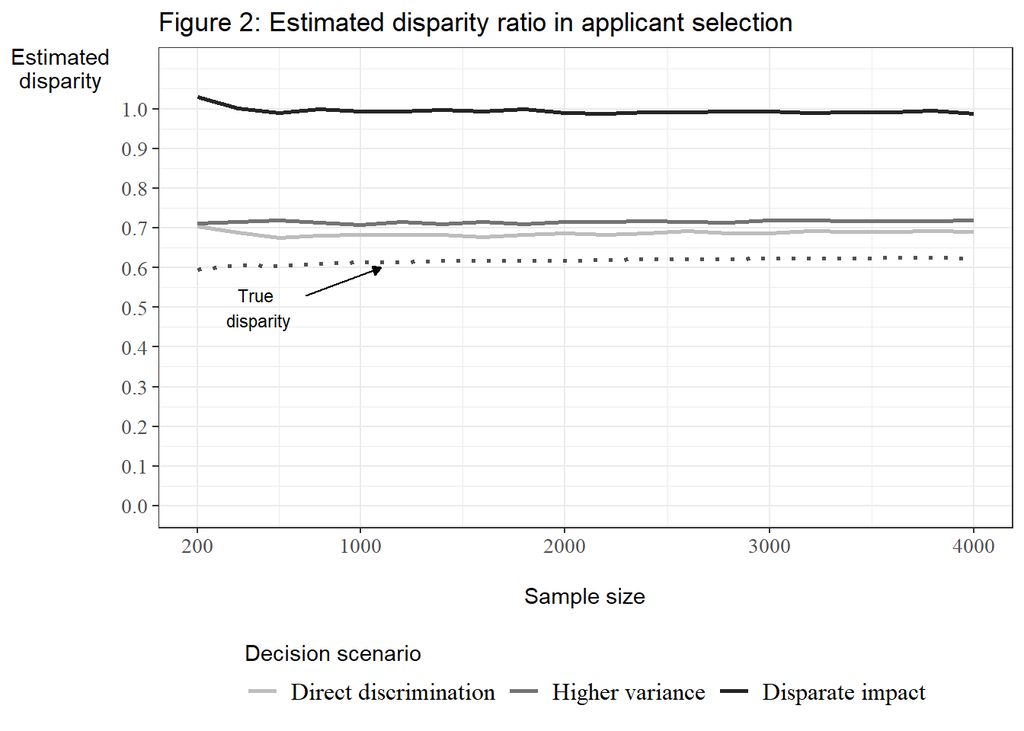

Additionally, the estimating equations vary substantially in terms of detecting effects at a 0.05 significance level. Figure 3 below displays the average estimated p-value by scenario and sample sizes. Scenario 1 is identified by the model once there’s a sample size of 1000 Scenario 2, which is more variable in how the the landlord makes a discriminatory decision, unsurprisingly requires a larger sample size to detect the effect, needing a minimum sample size of 1200.

However, in scenario 3, the model is unable to detect a significant effect at any sample size. This scenario is the canonical case where disparate impact tests would be most useful since the landlord’s decision-making did not depend on race per se (i.e. no intent) but led to a disparate impact. This result should be unsurprising based on the data generating process above (since the model controls for both earnings and former incarceration status, there is no possibility for the race variable to generate an effect).

This result also aligns with existing scholarship which criticizes the use of examining the treatment effect of race as a measure of discrimination. [Kohler-Hausmann, 2019](https://scholarlycommons.law.northwestern.edu/cgi/viewcontent.cgi?article=1374&context=nulr); [Heckman, 1998](https://www.aeaweb.org/articles?id=10.1257/jep.12.2.101). Since the model controls for variables causally related to race, which is a routine practice done during disparate impact analyses, the model removes many of the factors causing discriminatory impacts due to race. Previous scholars have described this as the “included variable bias” ([Ayres, 2010](https://www.law.upenn.edu/live/files/1138-ayresincludedvariablebiaspdf); [Jung et al., 2023](https://5harad.com/papers/included-variable-bias.pdf)). In particular Jung et al., 2023 demonstrates that by weighting averages of differences across groups balanced by control covariates, it might be possible to identify the actual disparity.

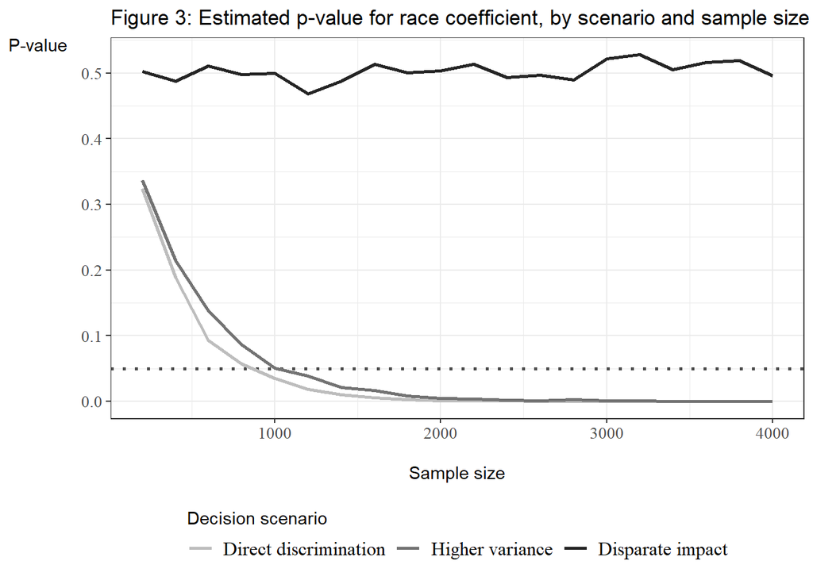

With this research in mind, this study will aim to construct synthetic datasets which contain properties matching datasets used in existing cases on disparate impact. Through the use of these synthetic datasets, we will examine how often current procedures are able to recover known disparate impacts and meet the rule standards, given increased sample sizes or modifications to model specifications addressing included-variable bias. Additionally, we will explore the extent to which it is possible to apply potential solutions to included-variable bias, since this is essential bias to resolve given the purpose of disparate impact cases (e.g., scenario 3 above). We will also assess how the use of these tests may modify the ability to meet the two rule standards of disparate impact testing: the four-fifths rule and the statistical significance standard.